# Project

2023-02-14

```r
library(tidyverse)
Hotel_Reservations <- read.csv("C:\\Users\\solan\\OneDrive\\Desktop\\Work\\St.Clair_sem_1\\DAB501_basic_stats\\DAB501\\Project\\Hotel_Reservations.csv", header=TRUE, stringsAsFactors=FALSE)
```

```r
str(Hotel_Reservations)
```

```
## 'data.frame':    36275 obs. of  19 variables:
##  $ Booking_ID                          : chr  "INN00001" "INN00002" "INN00003" "INN00004" ...
##  $ no_of_adults                        : int  2 2 1 2 2 2 2 2 3 2 ...
##  $ no_of_children                      : int  0 0 0 0 0 0 0 0 0 0 ...
##  $ no_of_weekend_nights                : int  1 2 2 0 1 0 1 1 0 0 ...
##  $ no_of_week_nights                   : int  2 3 1 2 1 2 3 3 4 5 ...
##  $ type_of_meal_plan                   : chr  "Meal Plan 1" "Not Selected" "Meal Plan 1" "Meal Plan 1" ...
##  $ required_car_parking_space          : int  0 0 0 0 0 0 0 0 0 0 ...
##  $ room_type_reserved                  : chr  "Room_Type 1" "Room_Type 1" "Room_Type 1" "Room_Type 1" ...
##  $ lead_time                           : int  224 5 1 211 48 346 34 83 121 44 ...
##  $ arrival_year                        : int  2017 2018 2018 2018 2018 2018 2017 2018 2018 2018 ...
##  $ arrival_month                       : int  10 11 2 5 4 9 10 12 7 10 ...
##  $ arrival_date                        : int  2 6 28 20 11 13 15 26 6 18 ...
##  $ market_segment_type                 : chr  "Offline" "Online" "Online" "Online" ...
##  $ repeated_guest                      : int  0 0 0 0 0 0 0 0 0 0 ...
##  $ no_of_previous_cancellations        : int  0 0 0 0 0 0 0 0 0 0 ...
##  $ no_of_previous_bookings_not_canceled: int  0 0 0 0 0 0 0 0 0 0 ...
##  $ avg_price_per_room                  : num  65 106.7 60 100 94.5 ...
##  $ no_of_special_requests              : int  0 1 0 0 0 1 1 1 1 3 ...
##  $ booking_status                      : chr  "Not_Canceled" "Not_Canceled" "Canceled" "Canceled" ...
```

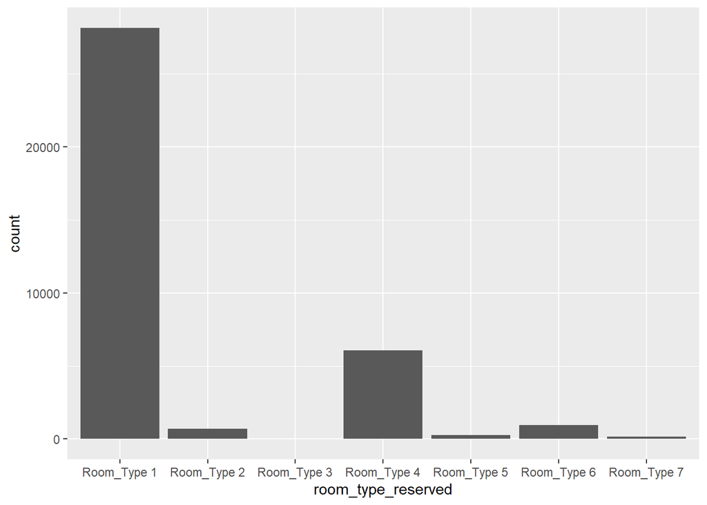

```r
ggplot(Hotel_Reservations) +
  stat_count(mapping = aes(x = room_type_reserved))
```

2) Type of meals

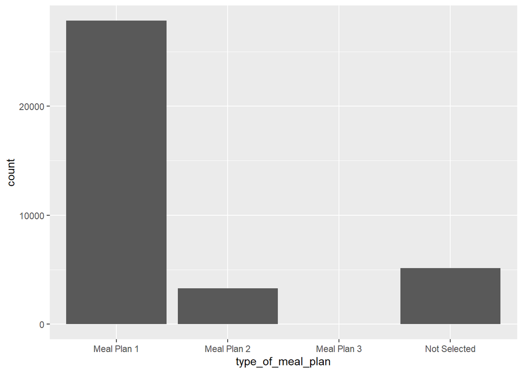

```r
ggplot(Hotel_Reservations) +
  stat_count(mapping = aes(x = type_of_meal_plan))
```

3. market_segment_type

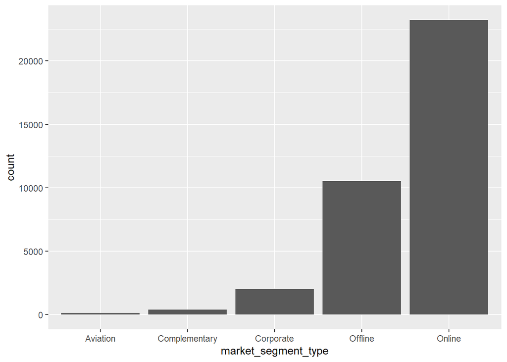

```r
ggplot(Hotel_Reservations) +
  stat_count(mapping = aes(x = market_segment_type))
```

4. booking_status

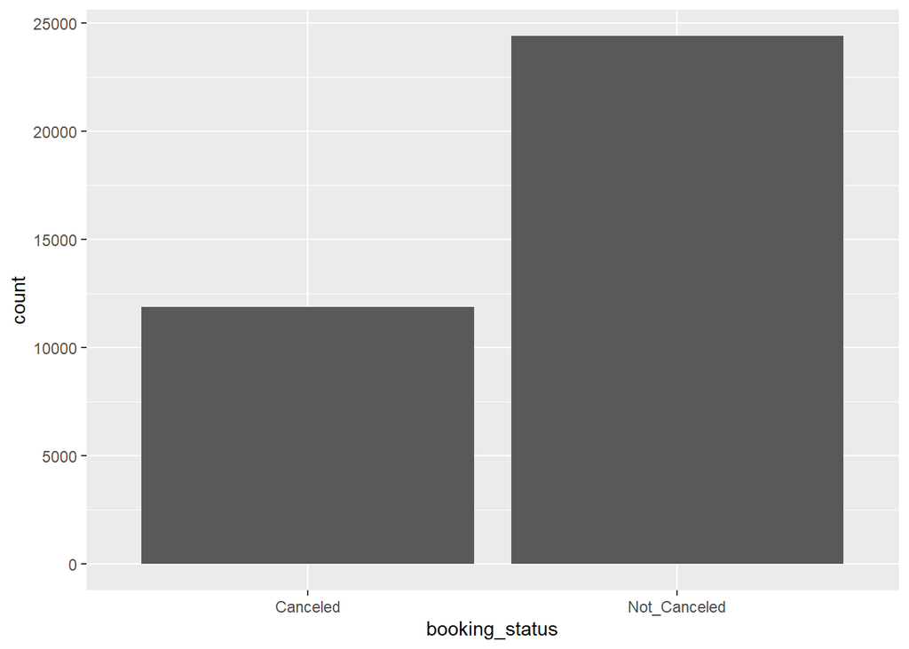

```r
ggplot(Hotel_Reservations) +
  stat_count(mapping = aes(x = booking_status))
```

#Now we will do the countinuous variables

1. no_of_adults

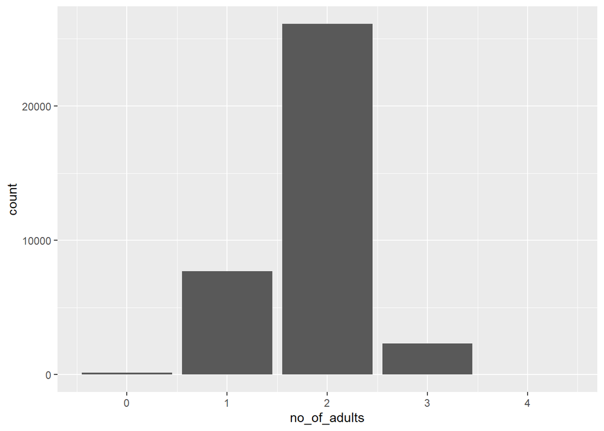

```r
ggplot(Hotel_Reservations) +
  stat_count(mapping = aes(x = no_of_adults))
```

2. no_of_children

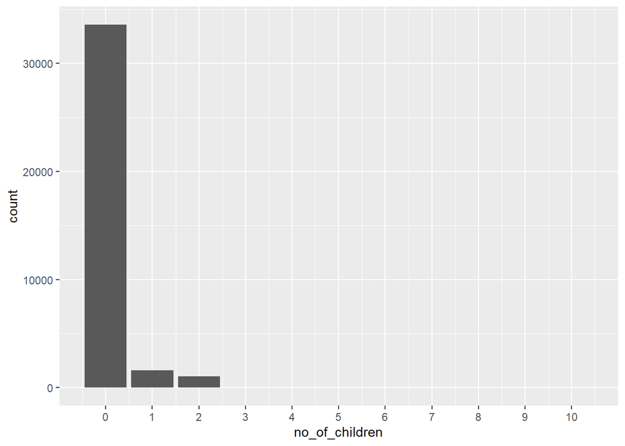

```r
ggplot(Hotel_Reservations) +
  stat_count(mapping = aes(x = no_of_children)) +
  scale_x_continuous(breaks = seq(0, 10, by = 1))
```

3. no_of_weekend_nights

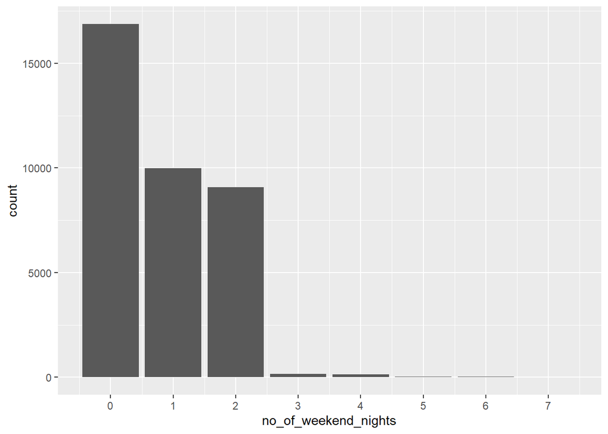

```r
ggplot(Hotel_Reservations) +
  stat_count(mapping = aes(x = no_of_weekend_nights)) +
  scale_x_continuous(breaks = seq(0, 10, by = 1))
```

4. no_of_week_nights

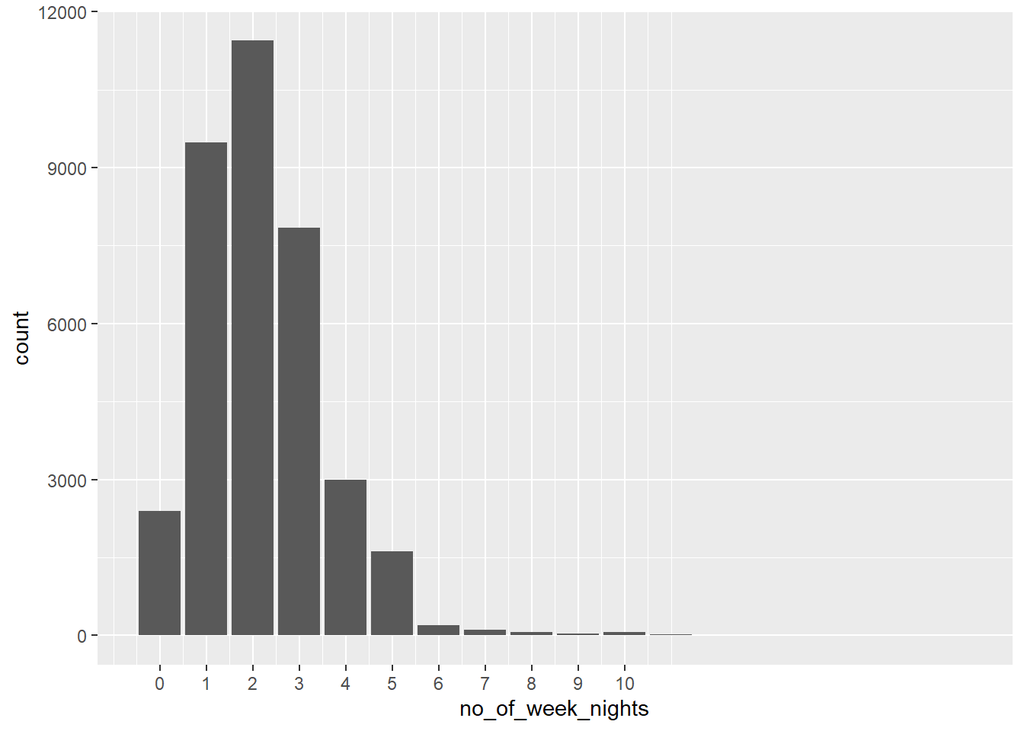

```r
ggplot(Hotel_Reservations) +
  stat_count(mapping = aes(x = no_of_week_nights)) +
  scale_x_continuous(breaks = seq(0, 10, by = 1))
```

5. required_car_parking_space

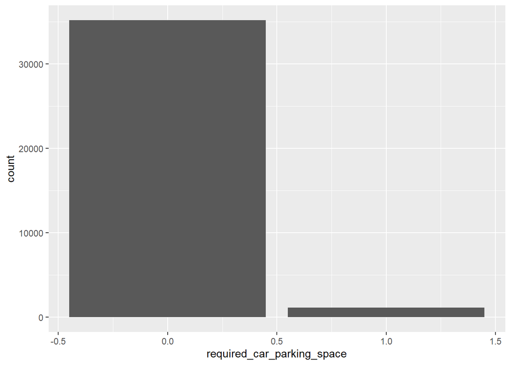

```r
ggplot(Hotel_Reservations) +
  stat_count(mapping = aes(x = required_car_parking_space))
```

6. lead_time

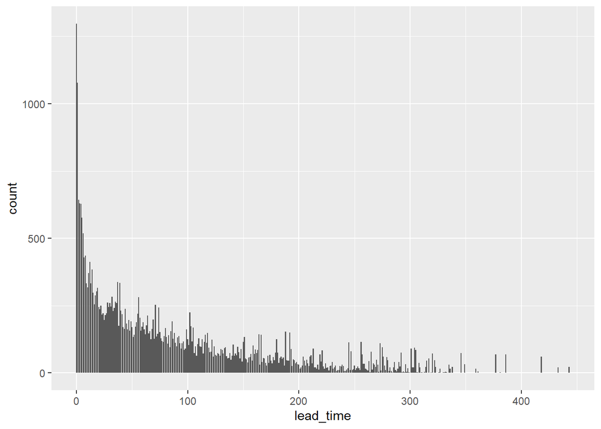

```r
ggplot(Hotel_Reservations) +
  stat_count(mapping = aes(x = lead_time))
```

7. arrival_year

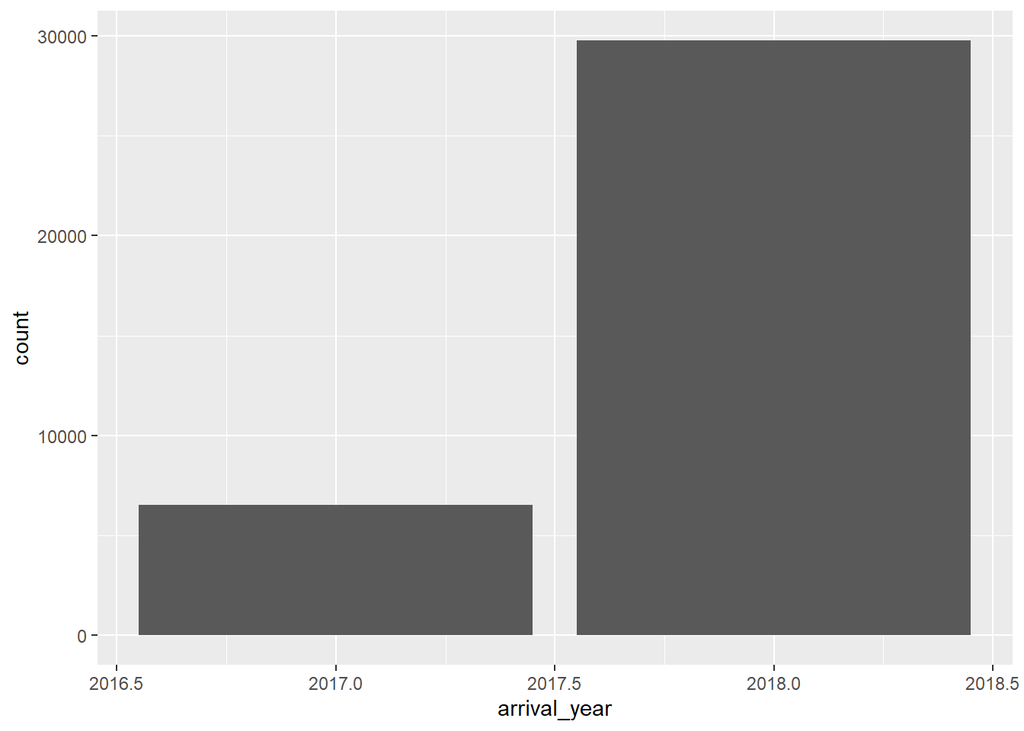

```r
ggplot(Hotel_Reservations) +
  stat_count(mapping = aes(x = arrival_year))
```

8. arrival_month

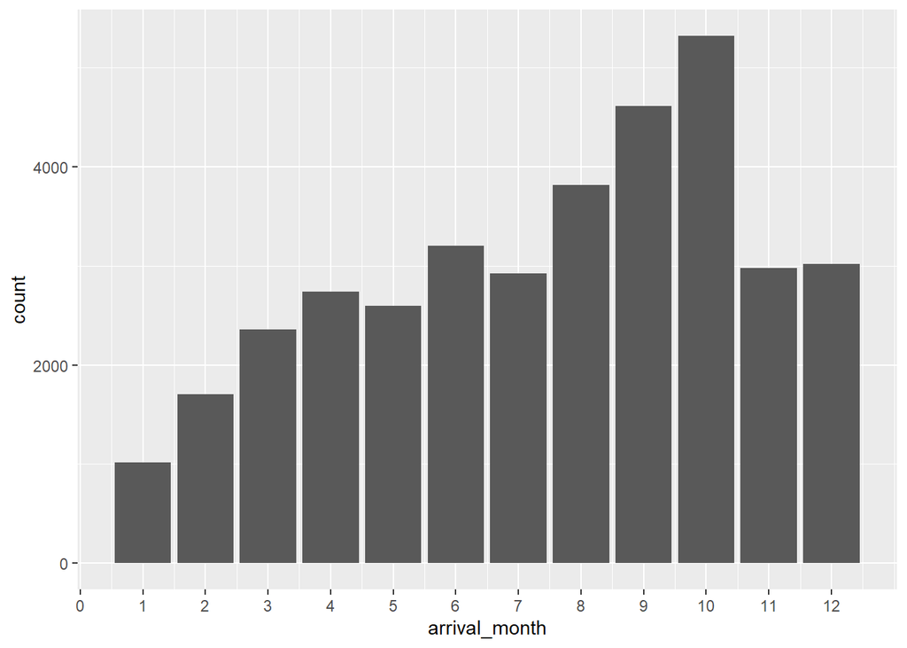

```r
ggplot(Hotel_Reservations) +
  stat_count(mapping = aes(x = arrival_month)) +
  scale_x_continuous(breaks = seq(0, 12, by = 1))
```

9. arrival_date

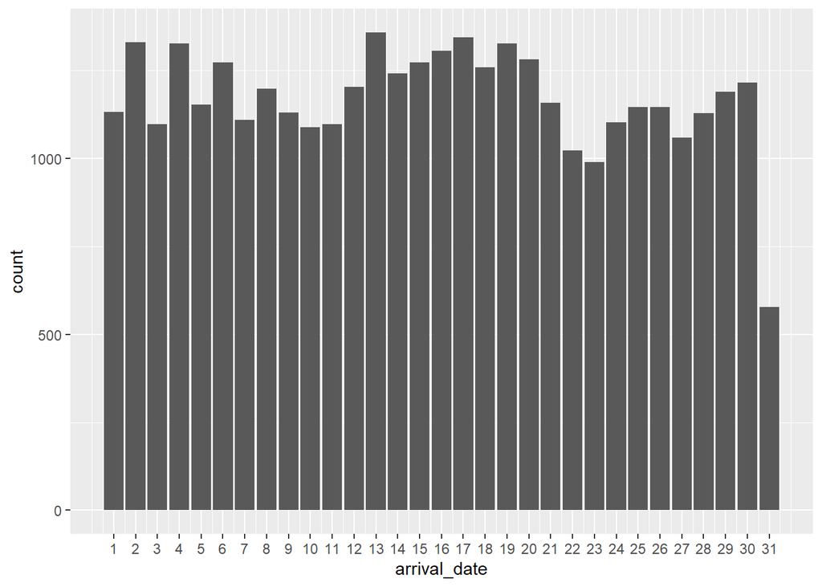

```r
ggplot(Hotel_Reservations) +
  stat_count(mapping = aes(x = arrival_date)) +
  scale_x_continuous(breaks = seq(1, 31, by = 1))
```

10. repeated_guest

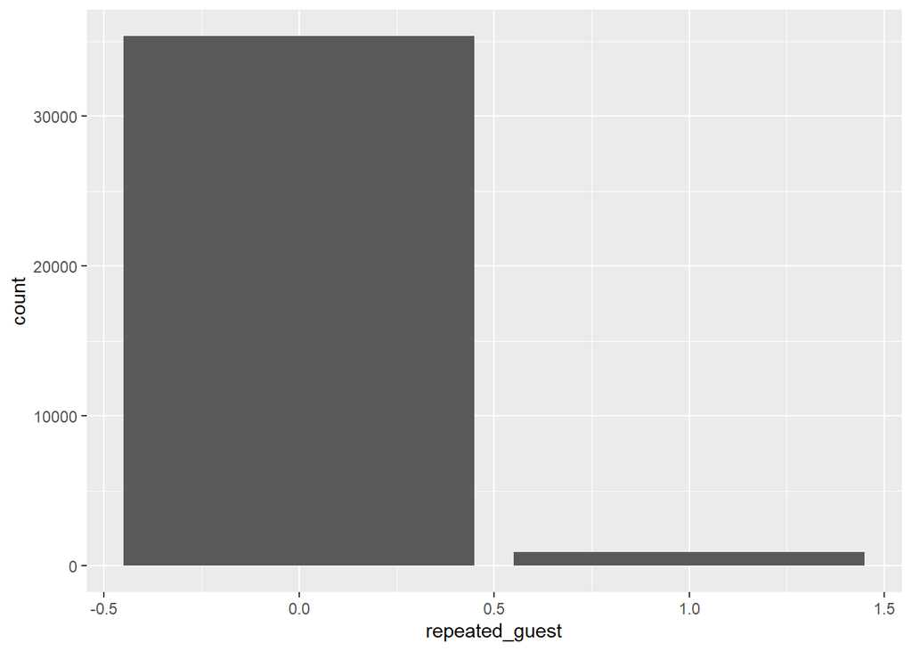

```r
ggplot(Hotel_Reservations) +
  stat_count(mapping = aes(x = repeated_guest))
```

11. no_of_previous_cancellations

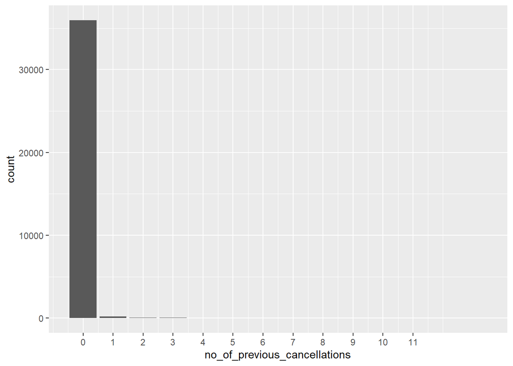

```r
ggplot(Hotel_Reservations) +
  stat_count(mapping = aes(x = no_of_previous_cancellations)) +
  scale_x_continuous(breaks = seq(0, 11, by = 1))
```

12. no_of_previous_bookings_not_canceled

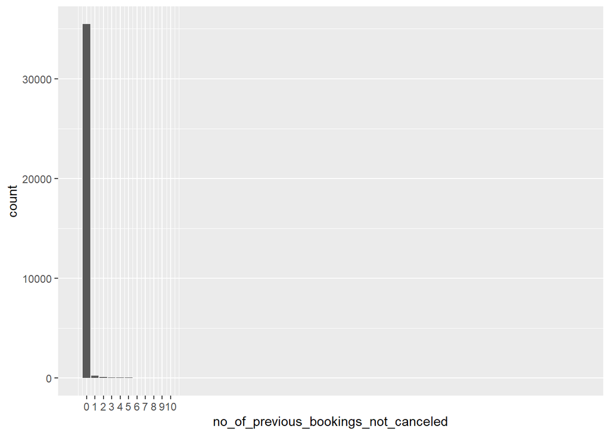

```r
ggplot(Hotel_Reservations) +
  stat_count(mapping = aes(x = no_of_previous_bookings_not_canceled)) +
  scale_x_continuous(breaks = seq(0, 10, by = 1))
```

12. avg_price_per_room

[figure not shown]

```r
ggplot(Hotel_Reservations) +
  stat_count(mapping = aes(x = avg_price_per_room))
```

13. no_of_special_requests

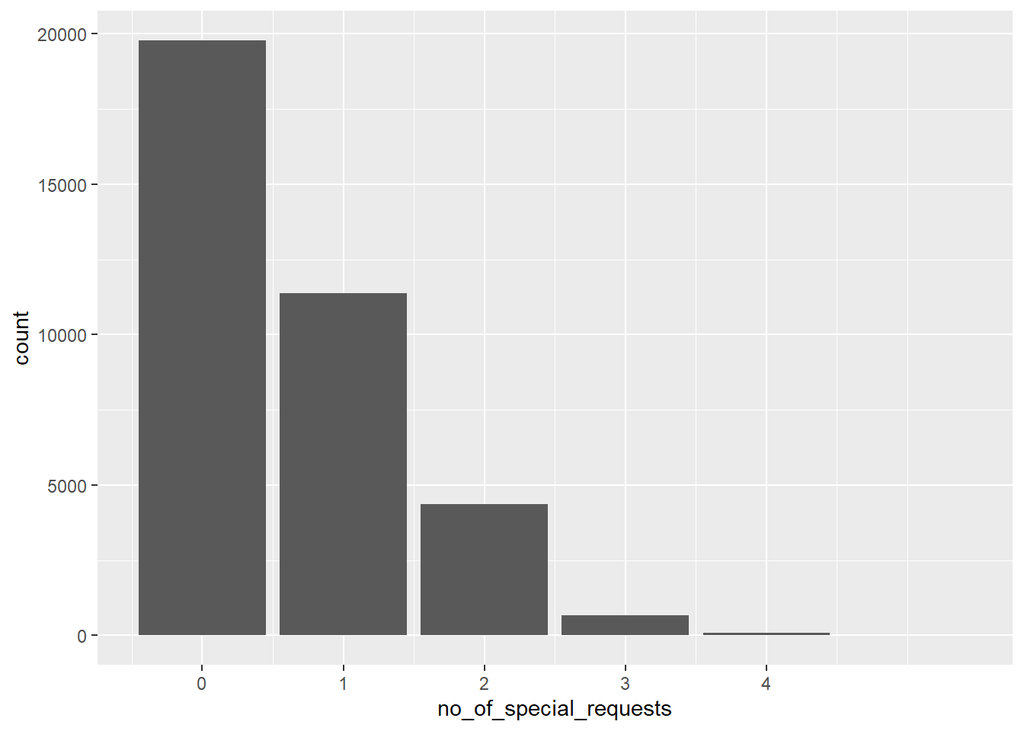

```r
ggplot(Hotel_Reservations) +
  stat_count(mapping = aes(x = no_of_special_requests)) +
  scale_x_continuous(breaks = seq(0, 4, by = 1))
```

14. Year and month with room type

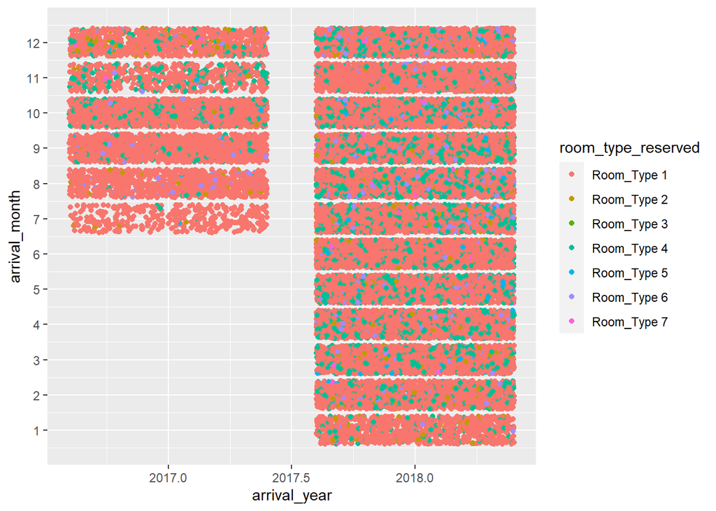

```r
ggplot(Hotel_Reservations) +
  geom_jitter(mapping = aes(x = arrival_year, y = arrival_month, color = room_type_reserved)) +
  scale_y_continuous(breaks = seq(1, 12, by = 1))
```

15. price and lead time with room type

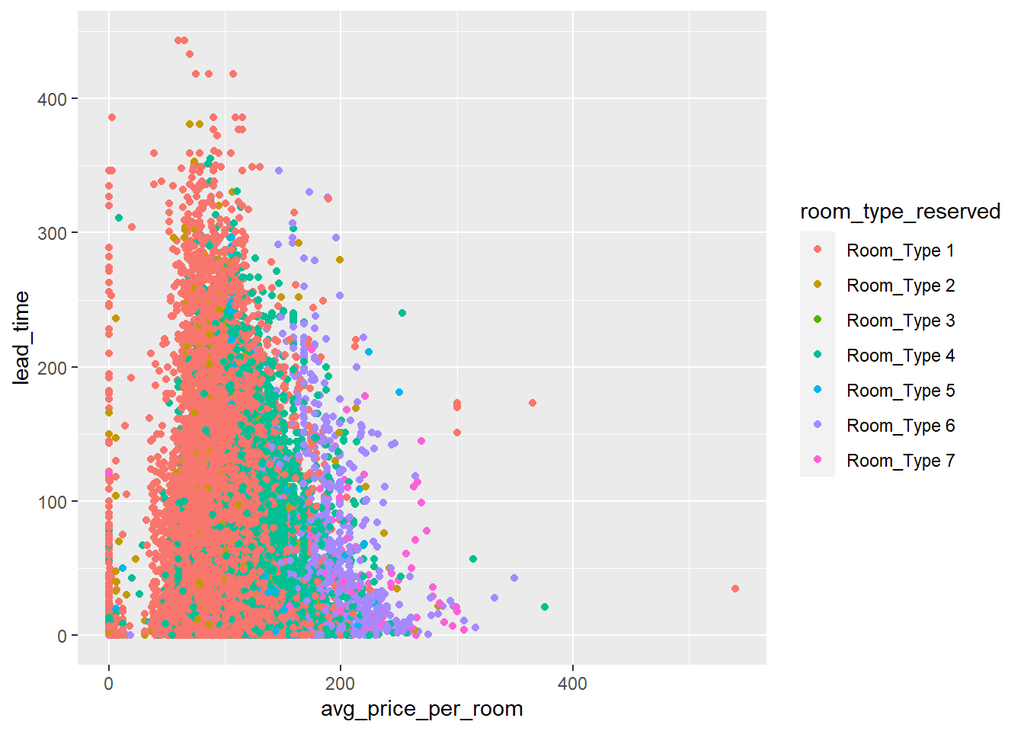

```r
ggplot(Hotel_Reservations) +
  geom_point(mapping = aes(x = avg_price_per_room, y = lead_time, color = room_type_reserved))
```

16. price and no of week nights with room type

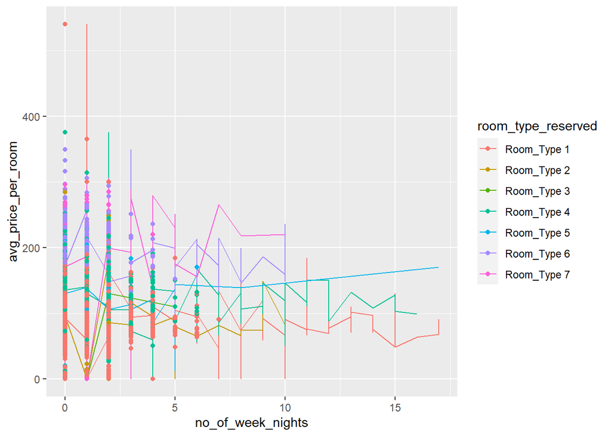

```r
ggplot(Hotel_Reservations) +
  geom_line(mapping = aes(y = avg_price_per_room, x = no_of_week_nights, color = room_type_reserved)) +
  geom_point(mapping = aes(y = avg_price_per_room, x = no_of_weekend_nights, color = room_type_reserved))
```

17. price and request with room type

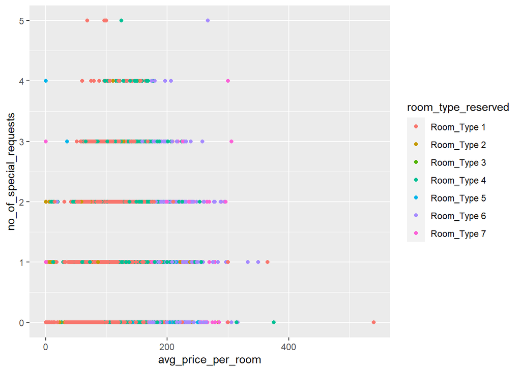

```r
ggplot(Hotel_Reservations) +
  geom_point(mapping = aes(x = avg_price_per_room, y = no_of_special_requests, color = room_type_reserved))
```

17. price and meal plan with room type

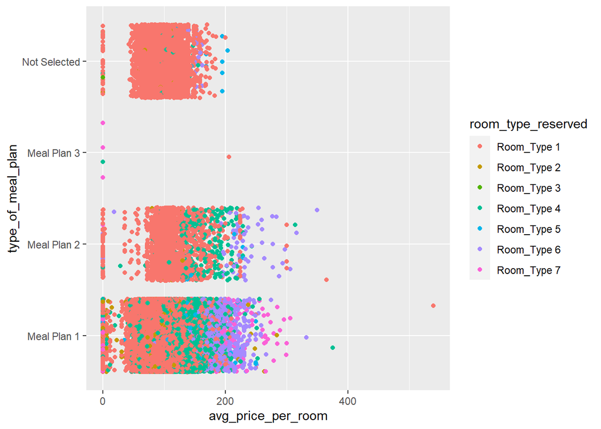

```r
ggplot(Hotel_Reservations) +
  geom_jitter(mapping = aes(x = avg_price_per_room, y = type_of_meal_plan, color = room_type_reserved))
```

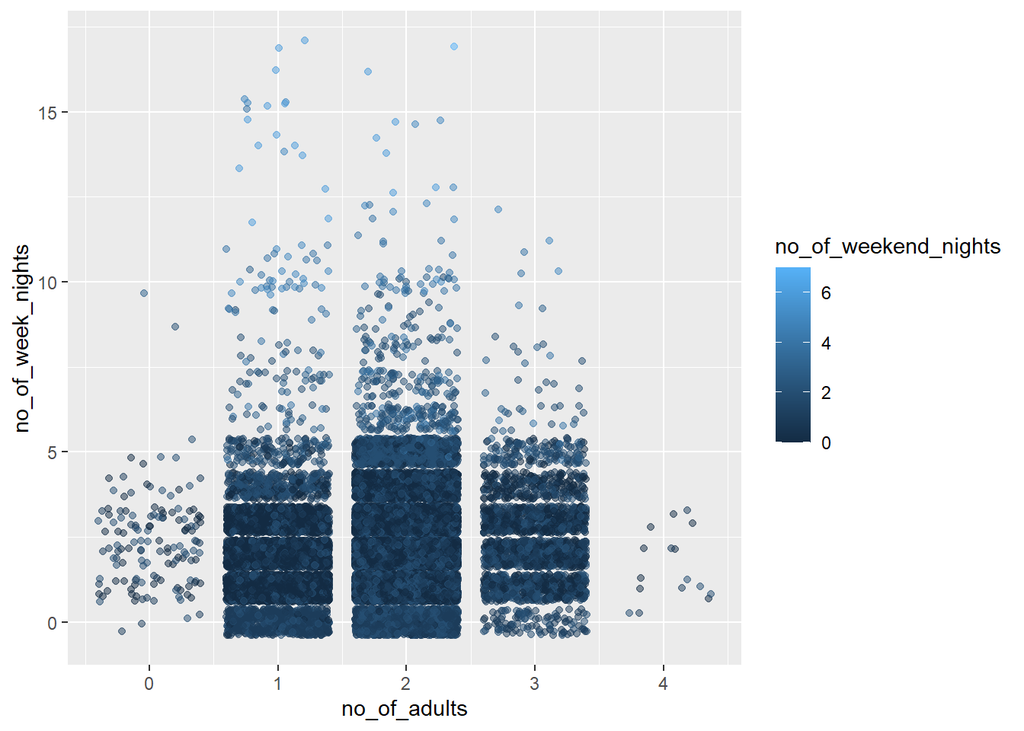

```r
ggplot(Hotel_Reservations, aes(x = no_of_adults, y = no_of_week_nights, color = no_of_weekend_nights)) +
  geom_jitter(alpha = 0.5)
```

19. price boxplot

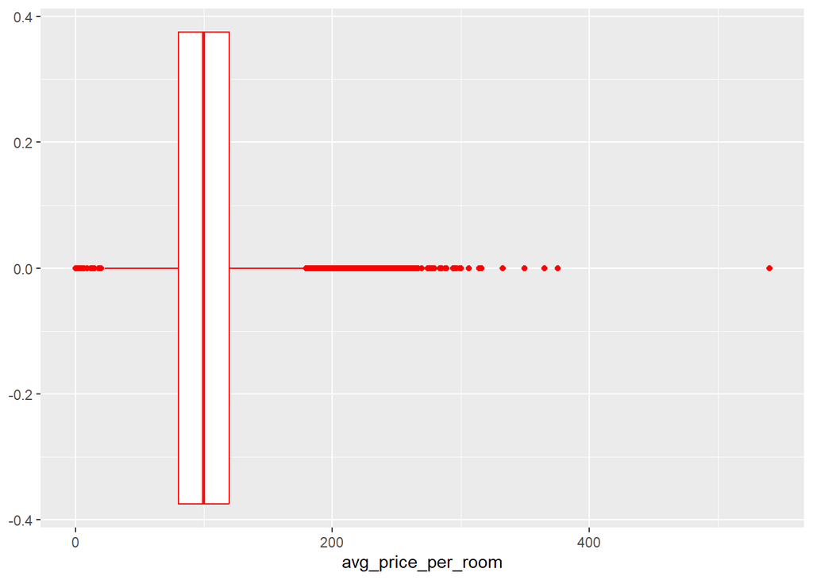

```r
ggplot(Hotel_Reservations)+
  geom_boxplot(aes(avg_price_per_room), color = "red", shape = 5)
```

19. arraival month histogram

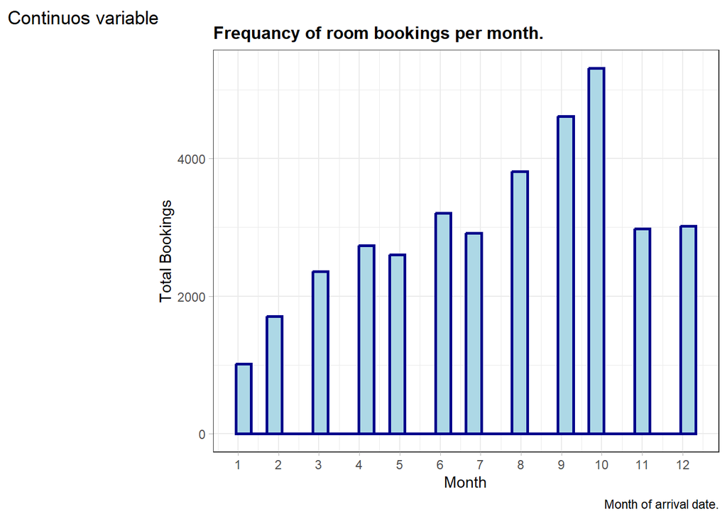

```r
ggplot(Hotel_Reservations)+
  geom_histogram(aes(arrival_month), color = "darkblue", fill = "lightblue", linetype = "solid", bins = 30, size = 1)+
  scale_x_continuous(breaks = scales::breaks_width(1))+
  labs(
    title = "Frequancy of room bookings per month.",
    caption = "Month of arrival date.",
    tag = "Continuos variable",
    x = "Month",
    y = "Total Bookings"
  )+
   theme_bw() +
  theme(plot.title = element_text(face = "bold", size = 12),
    axis.ticks = element_line(colour = "grey70", linewidth = 0.1))
```

19. Lead time area